# Data Essay Stadtentwicklung Stadt Zürich

Zufriedenheit mit Wohnungsangebot

Nicolas Aerni

2024-06-27

## Vorbemerkung

Für den vorliegenden Daten-Essay wurden Daten der Bevölkerungsbefragung der Stadt Zürich von [Stadt Zürich Open Data](https://data.stadt-zuerich.ch/dataset?q=bev%C3%B6lkerungsbefragung) verwendet. Die Daten wurden mit der Variable pgewicht gewichtet, um eine aussagekräftige Analyse zu ermöglichen.

**Show R code**

```r
rm(list=ls())

library(tidyverse)
library(magrittr)
library(hutils)
library(MASS)
library(viridis)
library(gridExtra)
library(lmtest)
library(knitr)
library(brant)
library(glm.predict)
# data load and preparation
#setwd("/Users/brutus/Desktop")
dat <- read.csv("bev473od4732.csv")

#outcome variable
#A2004ag01 Frage F4:7 Wohnungsangebot
dat$A2004ag01 %<>% as.factor()
#levels(dat$A2004ag01)

#covariates
dat$A2001aa01 %<>% as.factor()
#levels(dat$A2001aa01)
dat$A2001aa01 <- factor(dat$A2001aa01, levels = c("Keine Angabe","Sehr gerne", "Eher gerne", "Eher ungern", "Sehr ungern"))
dat$methode %<>% as.factor()
dat$Jahr %<>% as.factor()
dat$A1BVSKreis01 %<>% as.factor()
dat$A1BVSKreis01 <- factor(dat$A1BVSKreis01, levels = c("Kreis 1", "Kreis 2", "Kreis 3", "Kreis 4", "Kreis 5", "Kreis 6", "Kreis 7", "Kreis 8", "Kreis 9", "Kreis 10", "Kreis 11", "Kreis 12"))
#levels(dat$A1BVSKreis01)
dat$A1BVSAlterV03 %<>% as.factor()
#levels(dat$A1BVSAlterV03)
dat$A1BVSSex01 %<>% as.factor()
#levels(dat$A1BVSSex01)
dat$A3008aa01 <- as.numeric(dat$A3008aa01)
#summary(dat$A3008aa01)

df <- weight2rows(dat[,c("Jahr", "methode", "pgewicht", "A2001aa01", "A2004ag01", "A1BVSKreis01", "A1BVSAlterV03", "A1BVSSex01", "A3008aa01")], "pgewicht")
colnames(df) <- c("Jahr", "Methode", "PGewicht", "Beliebtheit", "Wohnungsangebot", "Kreis", "Alter", "Geschlecht", "Mietzins monatlich")
```

## Einführung

Die Stadt Zürich ist ein beliebter Lebensraum und die Wohnungsknappheit wird regelmässig in den Medien und in der Politik thematisiert. Gerade in den letzten Jahren war der Wohnungsmarkt von einer erhöhten Dynamik geprägt. So hat die Schweizerische Nationalbank auf die durch die Covid-19 Pandemie ausgelöste volatile Inflation mit einer Straffung ihrer Geldpolitik reagiert, die sich durch die Hypothekarzinssätze auf den Wohnungs- und unsbesondere den Mietermarkt übertragen hat. Kurzum: Die Mieten sind teurer geworden, was die Wahrnehmung zur Knappheit von bezahlbaren Wohnungen sicher weiter beeinflusst hat.

Für die vorliegende Analyse werden die Antworten auf die Frage “F4. Wie zufrieden sind Sie mit den folgenden Einrichtungen und Angeboten in der Stadt Zürich?” zum Item “Wohnungsangebot” untersucht.

Die folgenden zwei Heatmaps zeigen einerseits, dass sich die Zufriedenheit mit dem Wohnungsangebot in der Stadt Zürich zwischen 2021 und 2023 merklich verschlechtert hat (linke Grafik) und andererseits, dass die Bewohner*innen der Stadt Zürich im Jahr 2023 trotz einer hohen Unzufriedenheit mit dem Wohnungsangebot sehr gerne bis gerne in der Stadt wohnen (rechte Grafik).

**Show R code**

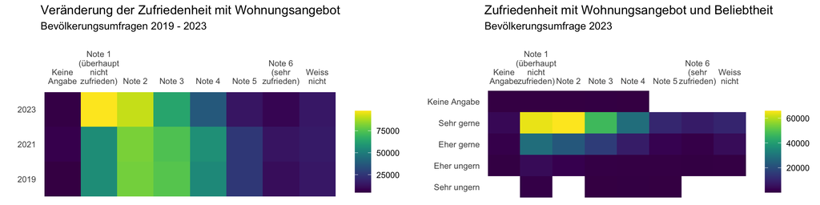

```r
#change of outcome variable over years
p.hmJahr <- ggplot(df, aes(Wohnungsangebot, Jahr)) +
  scale_fill_viridis(name="") +
  geom_bin2d() +
  scale_x_discrete(position = "top", labels = function(x) str_wrap(x, width = 10)) +
  scale_y_discrete() + #limits = rev(levels(df$Jahr))
  labs(title = "Veränderung der Zufriedenheit mit Wohnungsangebot",
       subtitle = "Bevölkerungsumfragen 2019 - 2023") +
    xlab(label = "") +
  ylab(label = "") +
  theme_minimal() +
  theme(panel.grid.major = element_blank(),
        panel.grid.minor = element_blank())

#just for 2023!
p.hmZufr <- ggplot(df[df$Jahr==2023,], aes(Wohnungsangebot, Beliebtheit)) +
  scale_fill_viridis(name="") +
  geom_bin2d() +
  scale_x_discrete(position = "top", labels = function(x) str_wrap(x, width = 10)) +
  scale_y_discrete(limits = rev(levels(df$Beliebtheit))) +
  labs(title = "Zufriedenheit mit Wohnungsangebot und Beliebtheit",
       subtitle = "Bevölkerungsumfrage 2023") +
    xlab(label = "") +
  ylab(label = "") +
  theme_minimal() +
  theme(panel.grid.major = element_blank(),
        panel.grid.minor = element_blank())
```

Wenn man die Zufriedenheit mit dem Wohnungsangebot nach Altersgruppen aufschlüsselt (linke Grafik, nur Umfragerunde 2023), dass die mittleren Altersklassen deutlich unzufriedener mit dem Wohnungsangebot sind als die jüngeren von 18 - 29 Jahre und die älteren Einwohner*innen ab 60 Jahren. Das mag daran liegen, dass die Gruppe der mittleren Altersklassen zwischen 30 und 59 Jahren die grösste Bevölkerungsschicht darstellt. Die Aufschlüsselung nach Geschlecht hingegen (rechte Grafik, ebenfalls nur Umfragerunde 2023) zeigt nur leichte Unterschiede in der Zufriedenheit mit dem Wohnungsangebot zwischen Männern und Frauen, was mit einem mehr oder weniger ausgeglichenen Geschlechter-Verhältnis zu erklären ist.

**Show R code**

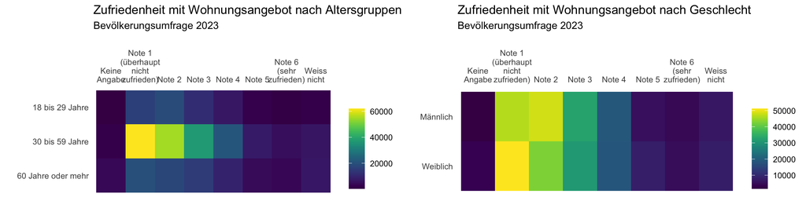

```r
p.hmAlter <- ggplot(df[df$Jahr==2023,], aes(x=Wohnungsangebot, y=Alter)) +
  scale_fill_viridis(name="") +
  geom_bin2d() +
  scale_x_discrete(position = "top", labels = function(x) str_wrap(x, width = 10)) +
  scale_y_discrete(limits = rev(levels(df$Alter))) +
  labs(title = "Zufriedenheit mit Wohnungsangebot nach Altersgruppen",
       subtitle = "Bevölkerungsumfrage 2023") +
    xlab(label = "") +
  ylab(label = "") +
  theme_minimal() +
  theme(panel.grid.major = element_blank(),
        panel.grid.minor = element_blank())

p.hmGeschl <- ggplot(df[df$Jahr==2023,], aes(Wohnungsangebot, Geschlecht)) +
  scale_fill_viridis(name="") +
  geom_bin2d() +
  scale_x_discrete(position = "top", labels = function(x) str_wrap(x, width = 10)) +
  scale_y_discrete(limits = rev(levels(df$Geschlecht))) +
  labs(title = "Zufriedenheit mit Wohnungsangebot nach Geschlecht",
       subtitle = "Bevölkerungsumfrage 2023") +
  xlab(label = "") +
  ylab(label = "") +
  theme_minimal() +
  theme(panel.grid.major = element_blank(),
        panel.grid.minor = element_blank())
```

## Hypothesen

**Show R code**

```r
#just for 2023!
fit1 <- polr(Wohnungsangebot ~ Alter + Geschlecht, data = df[df$Jahr==2023], Hess = TRUE, method = "logistic")
#summary(fit1)
#b1 <- brant(fit1)
#k.b1 <- kable(b1, digits = 3)
#if the probability (p-value) is greater than the alpha level (0.05), then the null hypothesis that the parameters (slope coefficients) are the same across response categories is accepted

ctable1 <- coef(summary(fit1))
p1 <- pnorm(abs(ctable1[, "t value"]), lower.tail = FALSE) * 2 # Rechnet mit Spalte "t value" als q zweiseitige p-Values
ctable1 <- cbind(ctable1, `p value` = round(p1, 3))
k1 <- kable(ctable1, caption = "Modell 1", digits = 3)

fit2 <- polr(Wohnungsangebot ~ Alter + Geschlecht + Kreis, data = df[df$Jahr==2023], Hess = TRUE, method = "probit")
#summary(fit2)
#b2 <- brant(fit2)
#k.b2 <- kable(b2, digits = 3)
#if the probability (p-value) is greater than the alpha level (0.05), then the null hypothesis that the parameters (slope coefficients) are the same across response categories is accepted
ctable2 <- coef(summary(fit2))
p2 <- pnorm(abs(ctable2[, "t value"]), lower.tail = FALSE) * 2 # Rechnet mit Spalte "t value" als q zweiseitige p-Values
ctable2 <- cbind(ctable2, `p value` = round(p2, 3))
k2 <- kable(ctable2, caption = "Modell 2", digits = 3)
```

Modell 1

|  | Value | Std. Error | t value | p value |
| --- | --- | --- | --- | --- |
| Alter30 bis 59 Jahre | -0.060 | 0.008 | -7.240 | 0 |
| Alter60 Jahre oder mehr | 0.288 | 0.010 | 29.492 | 0 |
| GeschlechtWeiblich | -0.053 | 0.006 | -8.614 | 0 |
| Keine Angabe\|Note 1 (überhaupt nicht zufrieden) | -4.112 | 0.016 | -264.639 | 0 |
| Note 1 (überhaupt nicht zufrieden)\|Note 2 | -0.803 | 0.008 | -99.296 | 0 |
| Note 2\|Note 3 | 0.341 | 0.008 | 42.793 | 0 |
| Note 3\|Note 4 | 1.246 | 0.008 | 150.271 | 0 |
| Note 4\|Note 5 | 2.071 | 0.009 | 228.555 | 0 |
| Note 5\|Note 6 (sehr zufrieden) | 2.572 | 0.010 | 260.261 | 0 |
| Note 6 (sehr zufrieden)\|Weiss nicht | 3.081 | 0.011 | 277.136 | 0 |

Das Modell 1 (ohne Stadtkreise) zeigt, dass die Variablen “Alter” (in 3 Altersklassen, Basiskategorie ist die Gruppe der Alter zwischen 18 - 29 Jahre), die Variable “Geschlecht” (die Basiskategorie ist männlich) sowie die Schnittpunkte der Antwortwahrscheinlichkeiten der Antwort-Variablen “Zufriedenheit” auf einem 99.9 % Level statistisch signifikant sind. Dies ist an der Spalte “p-Value” erkennbar.

Modell 2

|  | Value | Std. Error | t value | p value |
| --- | --- | --- | --- | --- |
| Alter30 bis 59 Jahre | -0.017 | 0.005 | -3.500 | 0.000 |
| Alter60 Jahre oder mehr | 0.148 | 0.006 | 25.866 | 0.000 |
| GeschlechtWeiblich | -0.039 | 0.004 | -10.843 | 0.000 |
| KreisKreis 2 | 0.012 | 0.017 | 0.704 | 0.481 |
| KreisKreis 3 | -0.009 | 0.016 | -0.522 | 0.601 |
| KreisKreis 4 | -0.129 | 0.017 | -7.596 | 0.000 |
| KreisKreis 5 | 0.104 | 0.018 | 5.753 | 0.000 |
| KreisKreis 6 | 0.074 | 0.017 | 4.396 | 0.000 |
| KreisKreis 7 | 0.181 | 0.017 | 10.896 | 0.000 |
| KreisKreis 8 | 0.248 | 0.018 | 13.893 | 0.000 |
| KreisKreis 9 | 0.125 | 0.016 | 7.689 | 0.000 |
| KreisKreis 10 | 0.043 | 0.017 | 2.611 | 0.009 |
| KreisKreis 11 | 0.242 | 0.016 | 15.049 | 0.000 |
| KreisKreis 12 | 0.334 | 0.017 | 19.810 | 0.000 |
| Keine Angabe\|Note 1 (überhaupt nicht zufrieden) | -2.029 | 0.017 | -120.574 | 0.000 |
| Note 1 (überhaupt nicht zufrieden)\|Note 2 | -0.385 | 0.016 | -23.960 | 0.000 |
| Note 2\|Note 3 | 0.331 | 0.016 | 20.645 | 0.000 |
| Note 3\|Note 4 | 0.884 | 0.016 | 54.884 | 0.000 |
| Note 4\|Note 5 | 1.345 | 0.016 | 83.003 | 0.000 |
| Note 5\|Note 6 (sehr zufrieden) | 1.600 | 0.016 | 98.261 | 0.000 |
| Note 6 (sehr zufrieden)\|Weiss nicht | 1.842 | 0.016 | 112.205 | 0.000 |

Im Modell 2 (mit Stadtkreisen) ist ersichtlich, dass die bisherigen Variablen “Alter” sowie “Geschlecht” ebenfalls statistisch signifikant sind. Zusätzlich zeigt Modell 2, dass für die Stadtkreise ebenfalls grösstenteils signifikante Koeffizienten auf Basis der Umfragedaten geschätzt werden können. Nur die Kreise 2 und 3 zeigen keine auf einem üblichen Konfidenzniveau signifikanten p-Werte.

**Show R code**

```r
lrtest(fit1, fit2)
```

```
## Likelihood ratio test
##
## Model 1: Wohnungsangebot ~ Alter + Geschlecht
## Model 2: Wohnungsangebot ~ Alter + Geschlecht + Kreis
##   #Df  LogLik Df  Chisq Pr(>Chisq)
## 1  10 -568126
## 2  21 -566040 11 4171.6  < 2.2e-16 ***
## ---
## Signif. codes:  0 '***' 0.001 '**' 0.01 '*' 0.05 '.' 0.1 ' ' 1
```

**Show R code**

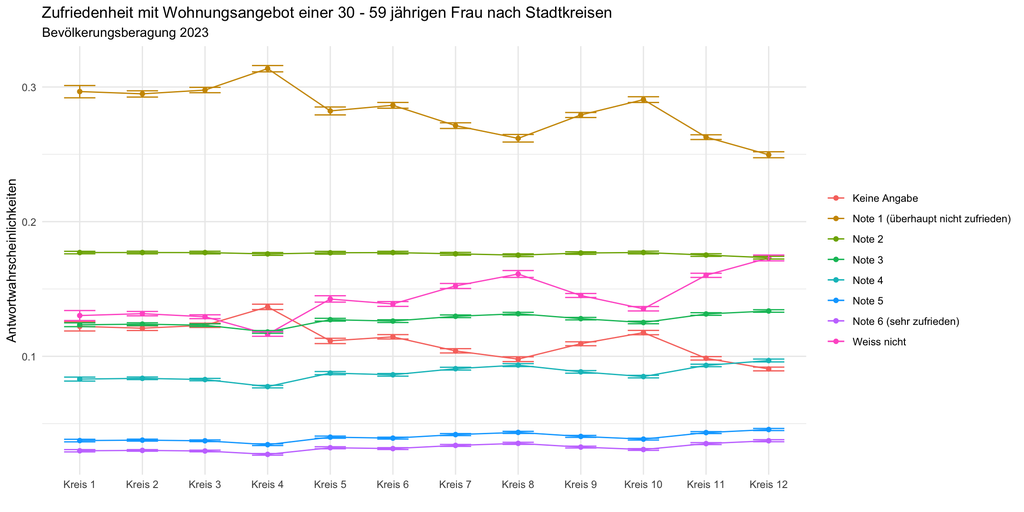

```r
output <- predicts(fit2, "mode;mode;all")
output$Kreis <- factor(output$Kreis, levels = c("Kreis 1", "Kreis 2", "Kreis 3", "Kreis 4", "Kreis 5", "Kreis 6", "Kreis 7", "Kreis 8", "Kreis 9", "Kreis 10", "Kreis 11", "Kreis 12"))

o1 <- ggplot(output, aes(x = Kreis, fill = level,col = level, y = mean)) +
geom_point() +
  geom_line(aes(group=level)) +
  scale_fill_discrete(name="")+
  scale_color_discrete(name="") +
geom_errorbar(aes(ymax = upper, ymin = lower), width=0.5) +
theme_minimal() +
ylab("Antwortwahrscheinlichkeiten") +
  xlab(label = "") +
  ggtitle("Zufriedenheit mit Wohnungsangebot einer 30 - 59 jährigen Frau nach Stadtkreisen", subtitle = "Bevölkerungsberagung 2023")
```

## Interpretation

Die Grafik zeigt, dass vor allem im Kreis 4 die Unzufriedenheit mit dem Wohnungsangebot am höchsten ausfällt, gefolgt von den Kreisen 3, 1, 2 sowie dem Kreis 10. Die tiefste Unzufriedenheit zeigt sich im Kreis 12, gefolgt vom Kreis 8. Allgemein hält sich eine grosse Zufriedenheit mit dem Wohnungsangebot über alle Kreise in sehr engen Grenzen. Diese Unterschiede in der Wahrnehmumg des verfügbaren Wohnungsangebots steht vermutlich mit deutlichen Unterschieden in den sozio-ökonomischen Merkmalen der Wohnbevölkerung in den verschiedenen Stadtkreisen in Zusammenhang. Eine weitere und vertiefte statistische Analyse müsste deshalb auf der Nachfrageseite mehr Variablen zu sozio-ökonomischen Merkmalen wie verfügbares Einkommen, Ausbildungsniveau, Beruf beinhalten. Weiter spielt sicher auch die jeweilige Lebenssituation der Wohnbevölkerung eine Rolle; Singles haben einen anderen Bedarf an Wohnraum als das Familien haben. Auf der Angebotsseite müsste berücksichtigt werden, wie der verfügbare Wohnraum benützt wird. Es ist davon auszugehen, dass es Unterschiede in der durchschnittlichen Nutzungsfläche pro Person zwischen den verschiedenen Stadtkreisen gibt. Dies soll an einem Beispiel illustriert werden: Eine Wohngenossenschaft, in der sich drei Personen in Wiedikon rund 100 m2 Wohnfläche teilen, wird wahrscheinlich unzufriedener sein mit einem knappen Wohnungsangebot als eine Einzelperson, der alleine eine 250 m2 grosse Villa am Zürichberg bewohnt.